[figure not shown]

# Welcome to the Data Science Coding Challange!

Test your skills in a real-world coding challenge. Coding Challenges provide CS & DS Coding Competitions with Prizes and achievement badges!

CS & DS learners want to be challenged as a way to evaluate if they’re job ready. So, why not create fun challenges and give winners something truly valuable such as complimentary access to select Data Science courses, or the ability to receive an achievement badge on their Coursera Skills Profile - highlighting their performance to recruiters.

## Introduction

In this challenge, you'll get the opportunity to tackle one of the most industry-relevant maching learning problems with a unique dataset that will put your modeling skills to the test. Subscription services are leveraged by companies across many industries, from fitness to video streaming to retail. One of the primary objectives of companies with subscription services is to decrease churn and ensure that users are retained as subscribers. In order to do this efficiently and systematically, many companies employ machine learning to predict which users are at the highest risk of churn, so that proper interventions can be effectively deployed to the right audience.

In this challenge, we will be tackling the churn prediction problem on a very unique and interesting group of subscribers on a video streaming service!

Imagine that you are a new data scientist at this video streaming company and you are tasked with building a model that can predict which existing subscribers will continue their subscriptions for another month. We have provided a dataset that is a sample of subscriptions that were initiated in 2021, all snapshotted at a particular date before the subscription was cancelled. Subscription cancellation can happen for a multitude of reasons, including:

- the customer completes all content they were interested in, and no longer need the subscription
- the customer finds themselves to be too busy and cancels their subscription until a later time
- the customer determines that the streaming service is not the best fit for them, so they cancel and look for something better suited

Regardless the reason, this video streaming company has a vested interest in understanding the likelihood of each individual customer to churn in their subscription so that resources can be allocated appropriately to support customers. In this challenge, you will use your machine learning toolkit to do just that!

## Understanding the Datasets

### Train vs. Test

In this competition, you’ll gain access to two datasets that are samples of past subscriptions of a video streaming platform that contain information about the customer, the customers streaming preferences, and their activity in the subscription thus far. One dataset is titled `train.csv` and the other is titled `test.csv`.

`train.csv` contains 70% of the overall sample (243,787 subscriptions to be exact) and importantly, will reveal whether or not the subscription was continued into the next month (the “ground truth”).

The `test.csv` dataset contains the exact same information about the remaining segment of the overall sample (104,480 subscriptions to be exact), but does not disclose the “ground truth” for each subscription. It’s your job to predict this outcome!

Using the patterns you find in the `train.csv` data, predict whether the subscriptions in `test.csv` will be continued for another month, or not.

### Dataset descriptions

Both `train.csv` and `test.csv` contain one row for each unique subscription. For each subscription, a single observation (`CustomerID`) is included during which the subscription was active.

In addition to this identifier column, the `train.csv` dataset also contains the target label for the task, a binary column `Churn`.

Besides that column, both datasets have an identical set of features that can be used to train your model to make predictions. Below you can see descriptions of each feature. Familiarize yourself with them so that you can harness them most effectively for this machine learning task!

```python
import pandas as pd
data_descriptions = pd.read_csv('data_descriptions.csv')
pd.set_option('display.max_colwidth', None)
data_descriptions
```

|  | Column_name | Column_type | Data_type | Description |
| --- | --- | --- | --- | --- |
| 0 | AccountAge | Feature | integer | The age of the user's account in months. |
| 1 | MonthlyCharges | Feature | float | The amount charged to the user on a monthly basis. |
| 2 | TotalCharges | Feature | float | The total charges incurred by the user over the account's lifetime. |
| 3 | SubscriptionType | Feature | object | The type of subscription chosen by the user (Basic, Standard, or Premium). |
| 4 | PaymentMethod | Feature | string | The method of payment used by the user. |
| 5 | PaperlessBilling | Feature | string | Indicates whether the user has opted for paperless billing (Yes or No). |
| 6 | ContentType | Feature | string | The type of content preferred by the user (Movies, TV Shows, or Both). |
| 7 | MultiDeviceAccess | Feature | string | Indicates whether the user has access to the service on multiple devices (Yes or No). |
| 8 | DeviceRegistered | Feature | string | The type of device registered by the user (TV, Mobile, Tablet, or Computer). |
| 9 | ViewingHoursPerWeek | Feature | float | The number of hours the user spends watching content per week. |
| 10 | AverageViewingDuration | Feature | float | The average duration of each viewing session in minutes. |
| 11 | ContentDownloadsPerMonth | Feature | integer | The number of content downloads by the user per month. |
| 12 | GenrePreference | Feature | string | The preferred genre of content chosen by the user. |
| 13 | UserRating | Feature | float | The user's rating for the service on a scale of 1 to 5. |
| 14 | SupportTicketsPerMonth | Feature | integer | The number of support tickets raised by the user per month. |
| 15 | Gender | Feature | string | The gender of the user (Male or Female). |
| 16 | WatchlistSize | Feature | float | The number of items in the user's watchlist. |
| 17 | ParentalControl | Feature | string | Indicates whether parental control is enabled for the user (Yes or No). |
| 18 | SubtitlesEnabled | Feature | string | Indicates whether subtitles are enabled for the user (Yes or No). |
| 19 | CustomerID | Identifier | string | A unique identifier for each customer. |
| 20 | Churn | Target | integer | The target variable indicating whether a user has churned or not (1 for churned, 0 for not churned). |

## How to Submit your Predictions to Coursera

Submission Format:

In this notebook you should follow the steps below to explore the data, train a model using the data in `train.csv`, and then score your model using the data in `test.csv`. Your final submission should be a dataframe (call it `prediction_df` with two columns and exactly 104,480 rows (plus a header row). The first column should be `CustomerID` so that we know which prediction belongs to which observation. The second column should be called `predicted_probability` and should be a numeric column representing the **likellihood that the subscription will churn**.

Your submission will show an error if you have extra columns (beyond `CustomerID` and `predicted_probability`) or extra rows. The order of the rows does not matter.

The naming convention of the dataframe and columns are critical for our autograding, so please make sure to use the exact naming conventions of `prediction_df` with column names `CustomerID` and `predicted_probability`!

To determine your final score, we will compare your `predicted_probability` predictions to the source of truth labels for the observations in `test.csv` and calculate the [ROC AUC](https://scikit-learn.org/stable/modules/generated/sklearn.metrics.roc_auc_score.html). We choose this metric because we not only want to be able to predict which subscriptions will be retained, but also want a well-calibrated likelihood score that can be used to target interventions and support most accurately.

## Import Python Modules

First, import the primary modules that will be used in this project. Remember as this is an open-ended project please feel free to make use of any of your favorite libraries that you feel may be useful for this challenge. For example some of the following popular packages may be useful:

- pandas
- numpy
- Scipy
- Scikit-learn
- keras
- maplotlib
- seaborn
- etc, etc

```python
# Import required packages
import seaborn as sns
# Data packages
import pandas as pd
import numpy as np

# Machine Learning / Classification packages
from sklearn.metrics import roc_auc_score
from sklearn.model_selection import train_test_split
from sklearn.dummy import DummyClassifier

# Visualization Packages
from matplotlib import pyplot as plt
import seaborn as sns
%matplotlib inline
```

## Load the Data

Let's start by loading the dataset `train.csv` into a dataframe `train_df`, and `test.csv` into a dataframe `test_df` and display the shape of the dataframes.

```python
train_df = pd.read_csv("train.csv")
print('train_df Shape:', train_df.shape)
train_df.head()
```

```
train_df Shape: (243787, 21)
```

|  | AccountAge | MonthlyCharges | TotalCharges | SubscriptionType | PaymentMethod | PaperlessBilling | ContentType | MultiDeviceAccess | DeviceRegistered | ViewingHoursPerWeek | ... | ContentDownloadsPerMonth | GenrePreference | UserRating | SupportTicketsPerMonth | Gender | WatchlistSize | ParentalControl | SubtitlesEnabled | CustomerID | Churn |
| --- | --- | --- | --- | --- | --- | --- | --- | --- | --- | --- | --- | --- | --- | --- | --- | --- | --- | --- | --- | --- | --- |
| 0 | 20 | 11.055215 | 221.104302 | Premium | Mailed check | No | Both | No | Mobile | 36.758104 | ... | 10 | Sci-Fi | 2.176498 | 4 | Male | 3 | No | No | CB6SXPNVZA | 0 |
| 1 | 57 | 5.175208 | 294.986882 | Basic | Credit card | Yes | Movies | No | Tablet | 32.450568 | ... | 18 | Action | 3.478632 | 8 | Male | 23 | No | Yes | S7R2G87O09 | 0 |
| 2 | 73 | 12.106657 | 883.785952 | Basic | Mailed check | Yes | Movies | No | Computer | 7.395160 | ... | 23 | Fantasy | 4.238824 | 6 | Male | 1 | Yes | Yes | EASDC20BDT | 0 |
| 3 | 32 | 7.263743 | 232.439774 | Basic | Electronic check | No | TV Shows | No | Tablet | 27.960389 | ... | 30 | Drama | 4.276013 | 2 | Male | 24 | Yes | Yes | NPF69NT69N | 0 |
| 4 | 57 | 16.953078 | 966.325422 | Premium | Electronic check | Yes | TV Shows | No | TV | 20.083397 | ... | 20 | Comedy | 3.616170 | 4 | Female | 0 | No | No | 4LGYPK7VOL | 0 |

5 rows × 21 columns

```python
test_df = pd.read_csv("test.csv")
print('test_df Shape:', test_df.shape)
test_df.head()
```

```
test_df Shape: (104480, 20)
```

|  | AccountAge | MonthlyCharges | TotalCharges | SubscriptionType | PaymentMethod | PaperlessBilling | ContentType | MultiDeviceAccess | DeviceRegistered | ViewingHoursPerWeek | AverageViewingDuration | ContentDownloadsPerMonth | GenrePreference | UserRating | SupportTicketsPerMonth | Gender | WatchlistSize | ParentalControl | SubtitlesEnabled | CustomerID |
| --- | --- | --- | --- | --- | --- | --- | --- | --- | --- | --- | --- | --- | --- | --- | --- | --- | --- | --- | --- | --- |
| 0 | 38 | 17.869374 | 679.036195 | Premium | Mailed check | No | TV Shows | No | TV | 29.126308 | 122.274031 | 42 | Comedy | 3.522724 | 2 | Male | 23 | No | No | O1W6BHP6RM |
| 1 | 77 | 9.912854 | 763.289768 | Basic | Electronic check | Yes | TV Shows | No | TV | 36.873729 | 57.093319 | 43 | Action | 2.021545 | 2 | Female | 22 | Yes | No | LFR4X92X8H |
| 2 | 5 | 15.019011 | 75.095057 | Standard | Bank transfer | No | TV Shows | Yes | Computer | 7.601729 | 140.414001 | 14 | Sci-Fi | 4.806126 | 2 | Female | 22 | No | Yes | QM5GBIYODA |
| 3 | 88 | 15.357406 | 1351.451692 | Standard | Electronic check | No | Both | Yes | Tablet | 35.586430 | 177.002419 | 14 | Comedy | 4.943900 | 0 | Female | 23 | Yes | Yes | D9RXTK2K9F |
| 4 | 91 | 12.406033 | 1128.949004 | Standard | Credit card | Yes | TV Shows | Yes | Tablet | 23.503651 | 70.308376 | 6 | Drama | 2.846880 | 6 | Female | 0 | No | No | ENTCCHR1LR |

## Explore, Clean, Validate, and Visualize the Data (optional)

Feel free to explore, clean, validate, and visualize the data however you see fit for this competition to help determine or optimize your predictive model. Please note - the final autograding will only be on the accuracy of the `prediction_df` predictions.

```python
### Data description
train_df.describe()
```

|  | AccountAge | MonthlyCharges | TotalCharges | ViewingHoursPerWeek | AverageViewingDuration | ContentDownloadsPerMonth | UserRating | SupportTicketsPerMonth | WatchlistSize | Churn |
| --- | --- | --- | --- | --- | --- | --- | --- | --- | --- | --- |
| count | 243787.000000 | 243787.000000 | 243787.000000 | 243787.000000 | 243787.000000 | 243787.000000 | 243787.000000 | 243787.000000 | 243787.000000 | 243787.000000 |
| mean | 60.083758 | 12.490695 | 750.741017 | 20.502179 | 92.264061 | 24.503513 | 3.002713 | 4.504186 | 12.018508 | 0.181232 |
| std | 34.285143 | 4.327615 | 523.073273 | 11.243753 | 50.505243 | 14.421174 | 1.155259 | 2.872548 | 7.193034 | 0.385211 |
| min | 1.000000 | 4.990062 | 4.991154 | 1.000065 | 5.000547 | 0.000000 | 1.000007 | 0.000000 | 0.000000 | 0.000000 |
| 25% | 30.000000 | 8.738543 | 329.147027 | 10.763953 | 48.382395 | 12.000000 | 2.000853 | 2.000000 | 6.000000 | 0.000000 |
| 50% | 60.000000 | 12.495555 | 649.878487 | 20.523116 | 92.249992 | 24.000000 | 3.002261 | 4.000000 | 12.000000 | 0.000000 |
| 75% | 90.000000 | 16.238160 | 1089.317362 | 30.219396 | 135.908048 | 37.000000 | 4.002157 | 7.000000 | 18.000000 | 0.000000 |
| max | 119.000000 | 19.989957 | 2378.723844 | 39.999723 | 179.999275 | 49.000000 | 4.999989 | 9.000000 | 24.000000 | 1.000000 |

```python
### Checking missing values
train_df.info()
```

```
<class 'pandas.core.frame.DataFrame'>
RangeIndex: 243787 entries, 0 to 243786
Data columns (total 21 columns):
 #   Column                    Non-Null Count   Dtype
---  ------                    --------------   -----
 0   AccountAge                243787 non-null  int64
 1   MonthlyCharges            243787 non-null  float64
 2   TotalCharges              243787 non-null  float64
 3   SubscriptionType          243787 non-null  object
 4   PaymentMethod             243787 non-null  object
 5   PaperlessBilling          243787 non-null  object
 6   ContentType               243787 non-null  object
 7   MultiDeviceAccess         243787 non-null  object
 8   DeviceRegistered          243787 non-null  object
 9   ViewingHoursPerWeek       243787 non-null  float64
 10  AverageViewingDuration    243787 non-null  float64
 11  ContentDownloadsPerMonth  243787 non-null  int64
 12  GenrePreference           243787 non-null  object
 13  UserRating                243787 non-null  float64
 14  SupportTicketsPerMonth    243787 non-null  int64
 15  Gender                    243787 non-null  object
 16  WatchlistSize             243787 non-null  int64
 17  ParentalControl           243787 non-null  object
 18  SubtitlesEnabled          243787 non-null  object
 19  CustomerID                243787 non-null  object
 20  Churn                     243787 non-null  int64
dtypes: float64(5), int64(5), object(11)
memory usage: 39.1+ MB
```

```python
# Checkig duplicates
train_df.duplicated("CustomerID").sum()
```

```
0
```

```python
# Separating numerical and categorical columns
target_train = train_df["Churn"]
data_train = train_df.drop(columns =["Churn","CustomerID"])
from sklearn.compose import make_column_selector as selector
categorical_column_selector = selector(dtype_include = object)
numerical_column_selector = selector(dtype_exclude = object)
categorical_features = categorical_column_selector(data_train)
numerical_features = numerical_column_selector(data_train)
```

```python
# Screening target
target_train.unique()
```

```
array([0, 1])
```

```python
#Checking the counts in each category of churn
target_train.value_counts()
```

```
0    199605
1     44182
Name: Churn, dtype: int64
```

```python
#Checking average Account age by churn category
train_df[["Churn","AccountAge"]].groupby("Churn").mean()
```

| Churn | AccountAge |
| --- | --- |
| 0 | 63.273290 |
| 1 | 45.674121 |

```python
#Checking Average Viewing Duration by churn category
train_df[["Churn","AverageViewingDuration"]].groupby("Churn").mean()
```

| Churn | AverageViewingDuration |
| --- | --- |
| 0 | 95.754533 |
| 1 | 76.494840 |

```python
# Checking churn categories distribution by gender
pd.crosstab(train_df["Churn"], train_df["Gender"])
```

| Gender Churn | Female | Male |
| --- | --- | --- |
| 0 | 100183 | 99422 |
| 1 | 21747 | 22435 |

```python
# Checking churn categories distribution by Subscription type
pd.crosstab(train_df["Churn"],train_df["SubscriptionType"])
```

| SubscriptionType Churn | Basic | Premium | Standard |
| --- | --- | --- | --- |
| 0 | 65122 | 67662 | 66821 |
| 1 | 15928 | 13155 | 15099 |

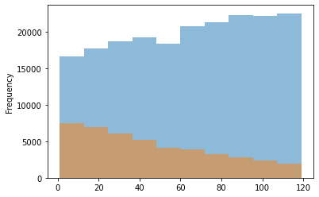

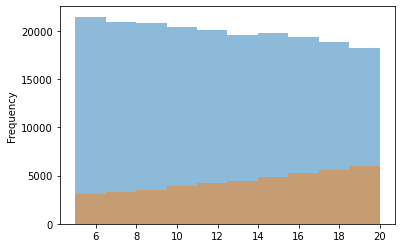

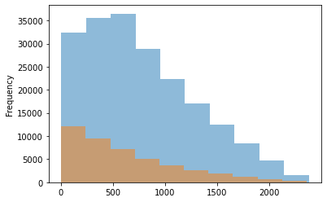

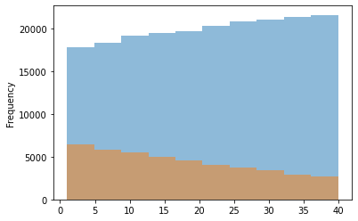

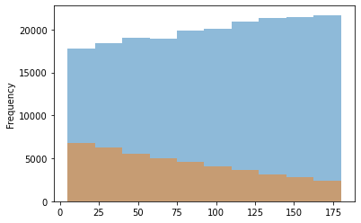

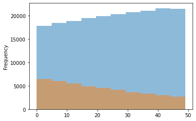

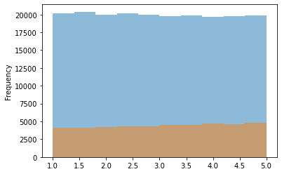

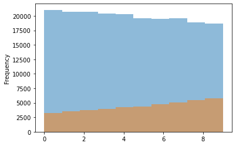

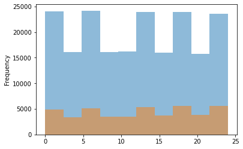

```python
#Visualizing data
for feature_name in numerical_features:
    plt.figure()
    train_df.groupby("Churn")[feature_name].plot.hist(alpha=0.5)
```

## Make predictions (required)

Remember you should create a dataframe named `prediction_df` with exactly 104,480 entries plus a header row attempting to predict the likelihood of churn for subscriptions in `test_df`. Your submission will throw an error if you have extra columns (beyond `CustomerID` and `predicted_probaility`) or extra rows.

The file should have exactly 2 columns: `CustomerID` (sorted in any order) `predicted_probability` (contains your numeric predicted probabilities between 0 and 1, e.g. from `estimator.predict_proba(X, y)[:, 1]`)

The naming convention of the dataframe and columns are critical for our autograding, so please make sure to use the exact naming conventions of `prediction_df` with column names `CustomerID` and `predicted_probability`!

### Example prediction submission:

**PLEASE CHANGE CODE BELOW TO IMPLEMENT YOUR OWN PREDICTIONS**

```python
# Building a preprocessor
from sklearn.preprocessing import OneHotEncoder,StandardScaler
categorical_preprocessor = OneHotEncoder(handle_unknown = "ignore")
numerical_preprocessor = StandardScaler()
```

```python
# Building a ColumnTransformer
from sklearn.compose import ColumnTransformer
preprocessor = ColumnTransformer([("one hot encoder", categorical_preprocessor, categorical_features),("standard scaler", numerical_preprocessor,numerical_features)])
```

```python
# Building a model pipeline based on Logistic Regression
from sklearn.linear_model import LogisticRegression
model = Pipeline([("preprocessor",preprocessor),("classifier",LogisticRegression())])
```

```python
#Hyperparameters tuning
param_grid = {
    'classifier__C': (1, 5, 10),}
model_grid_search = GridSearchCV(model, param_grid=param_grid, n_jobs=2, cv=2)
```

```python
#Fitting the model and finding the best parameters
model_grid_search.fit(data_train, target_train)
cv_results = pd.DataFrame(model_grid_search.cv_results_)
```

```python
cv_results
```

|  | mean_fit_time | std_fit_time | mean_score_time | std_score_time | param_classifier__C | params | split0_test_score | split1_test_score | mean_test_score | std_test_score | rank_test_score |
| --- | --- | --- | --- | --- | --- | --- | --- | --- | --- | --- | --- |
| 0 | 2.113325 | 0.092415 | 0.838650 | 0.039776 | 1 | {'classifier__C': 1} | 0.824561 | 0.824001 | 0.824281 | 0.00028 | 1 |
| 1 | 2.093833 | 0.119656 | 0.808728 | 0.012676 | 5 | {'classifier__C': 5} | 0.824561 | 0.824001 | 0.824281 | 0.00028 | 1 |
| 2 | 1.912471 | 0.018103 | 0.791072 | 0.010168 | 10 | {'classifier__C': 10} | 0.824561 | 0.824001 | 0.824281 | 0.00028 | 1 |

```python
# Use our dummy classifier to make predictions on test_df using `predict_proba` method:
predicted_probability = model_grid_search.predict_proba(test_df.drop(['CustomerID'], axis=1))[:,1]
```

```python
# Combine predictions with label column into a dataframe
prediction_df = pd.DataFrame({'CustomerID': test_df[['CustomerID']].values[:, 0],
                             'predicted_probability': predicted_probability})
```

```python
# View our 'prediction_df' dataframe as required for submission.
# Ensure it should contain 104,480 rows and 2 columns 'CustomerID' and 'predicted_probaility'
print(prediction_df.shape)
prediction_df.head()
```

```
(104480, 2)
```

|  | CustomerID | predicted_probability |
| --- | --- | --- |
| 0 | O1W6BHP6RM | 0.106343 |
| 1 | LFR4X92X8H | 0.040625 |
| 2 | QM5GBIYODA | 0.408319 |
| 3 | D9RXTK2K9F | 0.045012 |
| 4 | ENTCCHR1LR | 0.133128 |

**PLEASE CHANGE CODE ABOVE TO IMPLEMENT YOUR OWN PREDICTIONS**

## Final Tests - **IMPORTANT** - the cells below must be run prior to submission

Below are some tests to ensure your submission is in the correct format for autograding. The autograding process accepts a csv `prediction_submission.csv` which we will generate from our `prediction_df` below. Please run the tests below an ensure no assertion errors are thrown.

```python
# FINAL TEST CELLS - please make sure all of your code is above these test cells

# Writing to csv for autograding purposes
prediction_df.to_csv("prediction_submission.csv", index=False)
submission = pd.read_csv("prediction_submission.csv")

assert isinstance(submission, pd.DataFrame), 'You should have a dataframe named prediction_df.'
```

```python
# FINAL TEST CELLS - please make sure all of your code is above these test cells

assert submission.columns[0] == 'CustomerID', 'The first column name should be CustomerID.'
assert submission.columns[1] == 'predicted_probability', 'The second column name should be predicted_probability.'
```

```python
# FINAL TEST CELLS - please make sure all of your code is above these test cells

assert submission.shape[0] == 104480, 'The dataframe prediction_df should have 104480 rows.'
```

```python
# FINAL TEST CELLS - please make sure all of your code is above these test cells

assert submission.shape[1] == 2, 'The dataframe prediction_df should have 2 columns.'
```

```python
# FINAL TEST CELLS - please make sure all of your code is above these test cells

## This cell calculates the auc score and is hidden. Submit Assignment to see AUC score.
```

## SUBMIT YOUR WORK!

Once we are happy with our `prediction_df` and `prediction_submission.csv` we can now submit for autograding! Submit by using the blue **Submit Assignment** at the top of your notebook. Don't worry if your initial submission isn't perfect as you have multiple submission attempts and will obtain some feedback after each submission!